# bike_rent

Kar

2022-08-14

```r
library(tidyverse)
library(lubridate)
library(forecast)
library(prophet)
```

## 8 Bike Rental Forecast with Regressors

https://www.youtube.com/watch?v=sA0OqK6Mwc4&list=PL34t5iLfZddt9X6Q6aq0H38gn-_JQ1RjS&index=8

I will use Bike rental data available from Kaggle. We will start by simple time-series model that capture trends and seasonality.

Then we will add aggressors such as US holidays because Bike rental is usually affected by that, and also temperature and humidity.

The data is called “Bike Sharing in Washington D.C. Dataset” in Kaggle. Link: https://www.kaggle.com/datasets/marklvl/bike-sharing-dataset

Forecasting of rental bike is very useful for planning purposes.

### 8.1 Data & plot

```r
bike <- read.csv("bike.csv", header = T)

bike
```

```
##     instant     dteday season yr mnth holiday weekday workingday weathersit
## 1         1 2011-01-01      1  0    1       0       6          0          2
## 2         2 2011-01-02      1  0    1       0       0          0          2
## 3         3 2011-01-03      1  0    1       0       1          1          1
## 4         4 2011-01-04      1  0    1       0       2          1          1
## 5         5 2011-01-05      1  0    1       0       3          1          1
## 6         6 2011-01-06      1  0    1       0       4          1          1
## 7         7 2011-01-07      1  0    1       0       5          1          2
## 8         8 2011-01-08      1  0    1       0       6          0          2
## 9         9 2011-01-09      1  0    1       0       0          0          1
## 10       10 2011-01-10      1  0    1       0       1          1          1
## 11       11 2011-01-11      1  0    1       0       2          1          2
## 12       12 2011-01-12      1  0    1       0       3          1          1
## 13       13 2011-01-13      1  0    1       0       4          1          1
## 14       14 2011-01-14      1  0    1       0       5          1          1
```

[output cut: 1449 more lines]

We will use date column and “cnt”. cnt is the number of bike rented.

```r
bike <- bike %>% mutate(dteday = ymd(dteday))
```

Following plot shows that:

- We have complete two years of data.
- The data has seasonality and trend.
  - During winters, bike rental is low
  - During summers, bike rental is higher significantly

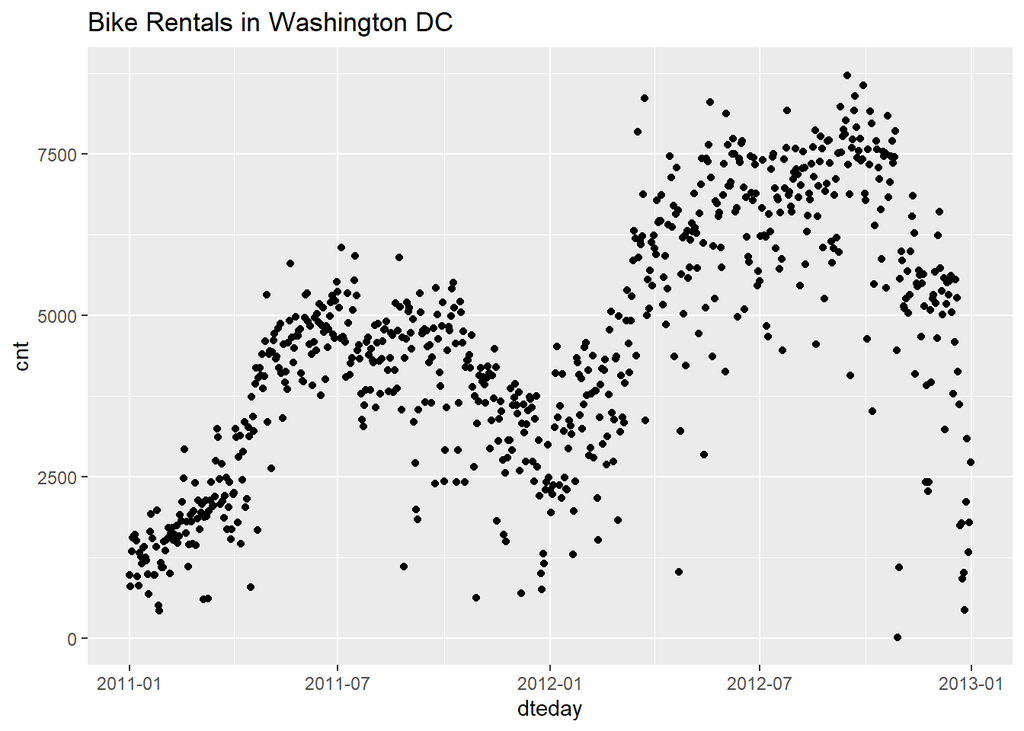

```r
qplot(x = dteday, y = cnt, data = bike) +
  labs(title = "Bike Rentals in Washington DC")
```

First we develop forecast based on date and bike-rental, then we add information of holidays in US because bike-rental might be affected. Later on, we add regressors such as temperature and humidity and see whether it will improve our bike rental forecasting model.

### 8.2 Model and Its performance

```r
ds <- bike$dteday
y <- bike$cnt

df.bike <- data.frame(ds, y)

# Prophet model

m.bike <- prophet(df = df.bike)
```

```
## Disabling daily seasonality. Run prophet with daily.seasonality=TRUE to override this.
```

```r
# forecast

future <- make_future_dataframe(m.bike, periods = 365)  # predict next 365 days
fc <- predict(m.bike, future)
```

Plot forecast

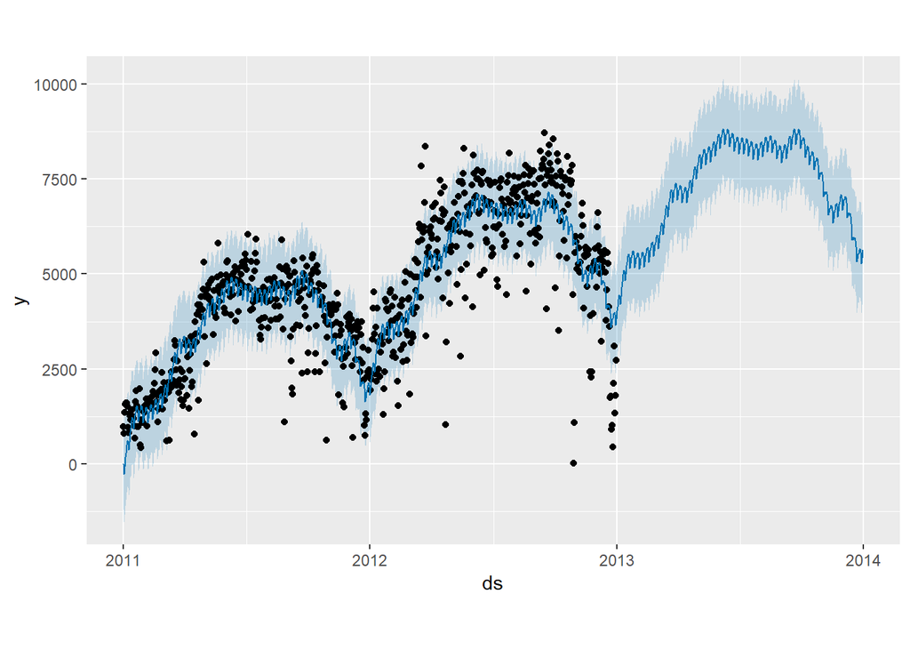

```r
plot(m.bike, fc)
```

```r
dyplot.prophet(m.bike, fc)
```

[interactive chart not shown]

It looks like a decent model because most of the data point fall within the confidence interval, and the model seems to capture the trends and seasonality nicely.